# PEC1_APR_jlarachu

M2.883 · Aprendizaje por refuerzo

2023-1 · Máster universitario en Ciencia de datos (*Data science*)

Estudios de Informática, Multimedia y Telecomunicación

**Nombre y apellidos:** Juan Lara Chups

# PEC 1 - Soluciones tabulares

En esta práctica implementaremos los diferentes métodos de aprendizaje por refuerzo vistos en las partes I y II del curso. En concreto, nos centraremos en la definición de un entorno e implementaremos los diferentes métodos para buscar una solución óptima del problema.

Consideraciones generales:

- Esta PEC debe realizarse de forma **estrictamente individual**. Cualquier indicio de copia será penalizado con un suspenso (D) para todas las partes implicadas y la posible evaluación negativa de la asignatura de forma íntegra.
- Es necesario que el estudiante indique **todas las fuentes** que ha utilizado para la realización de la PEC. De no ser así, se considerará que el estudiante ha cometido plagio, siendo penalizado con un suspenso (D) y la posible evaluación negativa de la asignatura de forma íntegra.

Formato de la entrega:

- Algunos ejercicios pueden suponer varios minutos de ejecución, por lo que la entrega debe hacerse en **formato notebook** y en **formato html**, donde se vea el código, los resultados y comentarios de cada ejercicio. Se puede exportar el notebook a HTML desde el menú File $\to$ Download as $\to$ HTML.
- Existe un tipo de celda especial para albergar texto. Este tipo de celda os será muy útil para responder a las diferentes preguntas teóricas planteadas a lo largo de la actividad. Para cambiar el tipo de celda a este tipo, en el menú: Cell $\to$ Cell Type $\to$ Markdown.

## 1. El entorno **Taxi** (1.5 pts)

El entorno **Taxi** es un entorno de cuadrícula de dimensiones 5x5 en el que el objetivo es llevar a un pasajero de un punto a otro. Hay 4 ubicaciones en el mapa (etiquetadas con letras diferentes) que pueden ser tanto el punto de recogida (marcado en color azul) como de entrega (marcado en color morado) del pasajero. Estos puntos van cambiando de forma aleatoria en cada episodio.

Vamos a empezar cargando el entorno y ver qué características tiene, ejecutando un episodio de prueba.

### 1.1. Carga de datos (0.5 pts)

El siguiente código carga los paquetes necesarios para ejecutar el ejemplo, crea el entorno mediante la instanciación de un objeto de la clase `TaxiEnv` (al ejecutar la instrucción `env=gym.make('Taxi-v3',render_mode="ansi")`) e imprime por pantalla el tipo del espacio de acciones, el del espacio de observaciones y el rango de la variable de recompensa (cuyo valor va de menos infinito a infinito).

```python
!pip install gymnasium==0.28.1
import gymnasium as gym
print("La versión de Gym utilizada en esta PEC es la 0.28.1, compruébalo a continuación")
print("Gym Version:", gym.__version__) # 0.28.1
```

```
     ━━━━━━━━━━━━━━━━━━━━━━━━━━━━━━━━━━━━━━━━ 925.5/925.5 kB 5.9 MB/s eta 0:00:00
La versión de Gym utilizada en esta PEC es la 0.28.1, compruébalo a continuación
Gym Version: 0.28.1
```

```python
from matplotlib import pyplot as plt
import numpy as np
```

```python
env=gym.make('Taxi-v3',render_mode="ansi")
print("Action space is {} ".format(env.action_space))
print("Observation space is {} ".format(env.observation_space))
print("Reward range is {} ".format(env.reward_range))
```

```
Action space is Discrete(6)
Observation space is Discrete(500)
Reward range is (-inf, inf)
```

**Ejercicio 1.1** (0.5 pts)

Analizar la [documentación](https://gymnasium.farama.org/environments/toy_text/taxi/) y responder a las siguientes preguntas:

- Describir el espacio de acciones del entorno: ¿cuantas acciones hay? ¿A qué corresponde cada una de ellas?
- Describir la señal de recompensa ¿Qué valores puede tomar? ¿En qué situaciones se recibe cada valor? </div>

**Comentarios:**  
El espacio de acciones de entorno se deducen a 6 (0:5). 0: moverse hacia el sur 1: moverse hacia el norte 2: moverse hacia el este 3: moverse hacia el oeste 4: recoger al pasajero 5: dejar al pasajero A su vez, la recompensa viene dada por las acciones correctas o incorrectas que realizamos en el entorno siendo sus valores los siguientes: - (-1) por paso realizado mientras no se active otra recompensa. - (+20) si se deja al pasajero en el lugar que le corresponde. - (-10) si se realiza la accion de recoger o dejar al pasajero de forma incorrecta

### 1.2. Ejecución de un episodio (0.5 pts)

A continuación, realizaremos la ejecución de un episodio del entorno `TaxiEnv` utilizando un agente que selecciona las acciones de forma aleatoria. Para realizar este apartado se recomienda analizar el código del entorno en el [repositorio de github](https://github.com/Farama-Foundation/Gymnasium/blob/main/gymnasium/envs/toy_text/taxi.py).

Empezamos reseteando el entorno e inspeccionando la observación inicial

```python
# Inicializamos el entorno
obs, info = env.reset()
t, total_reward, terminated, truncated = 0, 0, False, False
done = terminated or truncated
frame=env.render()
print(frame)
print("Observación inicial codificada: {} ".format(obs))
obs_decoded = [s for s in env.unwrapped.decode(obs)]
print("Observación inicial decodificada: {} ".format(obs_decoded))
print("Casilla actual del taxi: {} ".format((obs_decoded[0],obs_decoded[1])))
print("Posición del pasajero: {}".format(obs_decoded[2]))
print("Posición de destino: {}".format(obs_decoded[3]))
```

```
+---------+
|R: | : :G|
| : | : : |
| : : : : |
| | : | : |
|Y| : |B: |
+---------+


Observación inicial codificada: 289
Observación inicial decodificada: [2, 4, 2, 1]
Casilla actual del taxi: (2, 4)
Posición del pasajero: 2
Posición de destino: 1
```

Como puede observarse en la ejecución de la celda anterior. La observación de un estado se codifica como un número de 0 a 499 (en total 500 estados), siendo el estado original una tupla de 4 valores.

**Ejercicio 1.2** (0.5 pts)

Una vez analizado el código del entorno y la documentación del entorno y observando los resultados de la ejecución de la celda anterior (si se considera necesario ejecutarla varias veces), contestar a las siguientes preguntas:

- ¿A qué se corresponden los valores de los 4 números que conforman la tupla del estado sin codificar? ¿Qué rango de valores puede tomar cada elemento? ¿Cómo se almacena en el estado si el taxi ha recogido al pasajero?
- En base a la respuesta a la última pregunta del punto anterior ¿Por qué el número total de estados es 500? ¿Cómo se deduce a partir de los rangos de las variables que forman el estado? </div>

**Comentarios:**  
Los valores que contienen la tupla del estado sin codificar estan con formados por la ubicacion actual del taxi en el entorno en los dos primeros numeros, el 3º digito se refiere a la posicion donde se encuentra el pasajero y el ultimo digito se trata de la ubicacion de destino donde hay que dejar al pasajero. Los rangos de valores que pueden tomar son: - Para los dos primeros valores de 0 a 4. - Para la ubicacion del pasajero de 0 a 4 - Para la ubicacion de destino de 0 a 3. En el estado se almacena si el taxi ha recogido al pasajero si la tupla esta conformada por [x, y, 4, z] donde las letras son cualquier numero en el lrango descrito anterior y el 4 indica que el pasajero se encuentra en el vehiculo. El numero total de estados es 500 debido a que es el rango total de observaciones que se puede realizar desde [0,0,0,0] hasta [4,4,4,3]. segun el rango de los valores se deduce multiplicando las 25 posiciones que puede tener el taxi [0-4,0-4], las ubicaciones del pasajero [0-4] y las ubicaciones de destino [0-3]. Esto seria 5*5*5*4 = 500.

A continuación pasamos a ejecutar un episodio utilizando un agente que realiza acciones aleatorias. Daremos por finalizado el episodio tanto si se consigue el objetivo (llevar al pasajero a la celda de destino) como si se llega al número de pasos máximos establecido (200). En cada paso imprimiremos por pantalla la acción seleccionada, el estado siguiente y la recompensa obtenida. Finalmente imprimiremos el retorno (recompensa total) del episodio.

```python
switch_action = {
    0: "Move Down",
    1: "Move Up",
    2: "Move Right",
    3: "Move Left",
    4: "Pickup passenger",
    5: "Drop off passenger"
    }

while not done:

    # Elegir una acción aleatoria (ésta es la implementación del agente)
    action = env.action_space.sample()

    # Ejecutar la acción y esperar la respuesta del entorno
    new_obs, reward, terminated, truncated, info = env.step(action)
    done = terminated or truncated

    # Imprimir time-step
    print("Action: {} -> Obs: {} and reward: {}".format(switch_action[action], new_obs, reward))

    # Actualizar variables
    obs = new_obs
    total_reward += reward
    t += 1
print("\n")
print("Episode finished after {} timesteps and reward was {} ".format(t, total_reward))
```

```
Action: Move Down -> Obs: 389 and reward: -1
Action: Drop off passenger -> Obs: 389 and reward: -10
Action: Move Down -> Obs: 489 and reward: -1
Action: Move Right -> Obs: 489 and reward: -1
Action: Move Up -> Obs: 389 and reward: -1
Action: Move Right -> Obs: 389 and reward: -1
Action: Move Up -> Obs: 289 and reward: -1
Action: Move Right -> Obs: 289 and reward: -1
Action: Move Up -> Obs: 189 and reward: -1
Action: Move Down -> Obs: 289 and reward: -1
Action: Move Left -> Obs: 269 and reward: -1
Action: Move Down -> Obs: 369 and reward: -1
Action: Move Left -> Obs: 369 and reward: -1
Action: Drop off passenger -> Obs: 369 and reward: -10
Action: Move Right -> Obs: 389 and reward: -1
Action: Move Left -> Obs: 369 and reward: -1
Action: Pickup passenger -> Obs: 369 and reward: -10
Action: Move Right -> Obs: 389 and reward: -1
Action: Move Down -> Obs: 489 and reward: -1
Action: Move Right -> Obs: 489 and reward: -1
Action: Move Left -> Obs: 469 and reward: -1
Action: Move Down -> Obs: 469 and reward: -1
Action: Move Up -> Obs: 369 and reward: -1
Action: Drop off passenger -> Obs: 369 and reward: -10
Action: Drop off passenger -> Obs: 369 and reward: -10
Action: Move Up -> Obs: 269 and reward: -1
Action: Move Right -> Obs: 289 and reward: -1
Action: Move Right -> Obs: 289 and reward: -1
Action: Pickup passenger -> Obs: 289 and reward: -10
Action: Move Up -> Obs: 189 and reward: -1
Action: Move Left -> Obs: 169 and reward: -1
Action: Pickup passenger -> Obs: 169 and reward: -10
Action: Move Down -> Obs: 269 and reward: -1
Action: Move Left -> Obs: 249 and reward: -1
Action: Move Right -> Obs: 269 and reward: -1
Action: Drop off passenger -> Obs: 269 and reward: -10
Action: Drop off passenger -> Obs: 269 and reward: -10
Action: Move Left -> Obs: 249 and reward: -1
Action: Move Up -> Obs: 149 and reward: -1
Action: Move Right -> Obs: 169 and reward: -1
```

[output cut: 148 more lines]

```
Action: Drop off passenger -> Obs: 69 and reward: -10
Action: Pickup passenger -> Obs: 69 and reward: -10
Action: Move Right -> Obs: 89 and reward: -1
Action: Drop off passenger -> Obs: 89 and reward: -10
Action: Move Up -> Obs: 89 and reward: -1
Action: Move Up -> Obs: 89 and reward: -1
Action: Pickup passenger -> Obs: 89 and reward: -10
Action: Move Right -> Obs: 89 and reward: -1
Action: Pickup passenger -> Obs: 89 and reward: -10
Action: Pickup passenger -> Obs: 89 and reward: -10
Action: Drop off passenger -> Obs: 89 and reward: -10
Action: Move Left -> Obs: 69 and reward: -1


Episode finished after 200 timesteps and reward was -722
```

### 1.3. Ejecución de varios episodios y recolección de datos (0.5 pts)

A continuación ejecutaremos algunos episodios de forma aleatoria y recogeremos algunos datos para analizar la 'performance' del agente.

**Ejercicio 1.3** (0.5 pts)

Implementar una función que ejecute un algoritmo aleatorio durante un número de episodios determinado y que calcule:

- El número total de pasos realizados en el total de episodios.
- El número total de veces que se ha recibido una recompensa de -10 (que equivale al número de veces que se ha llevado a cabo la opción recoger o depositar al pasajero de forma errónea).
- La suma de los retornos de todos los episodios
- El número total de veces que se ha depositado correctamente al pasajero en el destino.

```python
"""Evaluate random agent's performance"""
def RA_evaluation(episodes=100):
    total_epochs, total_return, total_penalties, total_drops = 0, 0, 0, 0

    for episode in range(episodes):
        state, _ = env.reset()
        epochs, episode_return, penalties, drops = 0, 0, 0, 0
        done = False

        while not done:
            action = env.action_space.sample()  # Acción aleatoria
            next_state, reward, terminated, truncated, _ = env.step(action)
            done = terminated or truncated

            if reward == -10:
                penalties += 1

            epochs += 1
            episode_return += reward

            if done:
                if reward == 20:
                    drops += 1
                break

        total_epochs += epochs
        total_return += episode_return
        total_penalties += penalties
        total_drops += drops

    return total_epochs, total_penalties, total_return, total_drops
```

Una vez implementada la función procederemos a ejecutar unos cuantos episodios y comentar los resultados obtenidos.

```python
%%time
episodes = 1000

total_epochs, total_penalties, total_return, total_drops = RA_evaluation(episodes)

print("Resultados después de {} episodios:".format(episodes))
print("Número medio de iteraciones por episodio: {}".format(total_epochs / episodes))
print("Número medio de penalizaciones por episodio: {}".format(total_penalties / episodes))
print("Retorno medio por episodio: {}".format(total_return / episodes))
print("Porcentaje de entregas: {} %".format(total_drops*100 / episodes))
print("\n")
```

```
Resultados después de 1000 episodios:
Número medio de iteraciones por episodio: 196.041
Número medio de penalizaciones por episodio: 63.729
Retorno medio por episodio: -768.51
Porcentaje de entregas: 5.2 %


CPU times: user 6.65 s, sys: 375 ms, total: 7.03 s
Wall time: 7.64 s
```

## 2. Programación dinámica (0.5 puntos)

Los métodos de programación dinámica nos permiten llegar a la solución óptima de un MDP bajo ciertas condiciones.

**Ejercicio 2.1** (0.5 pts)

Comentar qué requisitos se requieren para utilizar dichos algoritmos ¿Por qué no es recomendable utilizarlos en un entorno como el que nos ocupa?

**Comentarios:**  
Segun los apuntes de la asignatura, para que los requisitos para utilizar los algotimos de programación dinamica son: - Conocer el modelo de transicion del entorno, es decir, la probabilidad de transicion entre estados despues de una acción. - Espacio de los estados y acciones finitos. - Seguir las condiciones de un MDP. No es recomendado utilizar estos algoritmos en el entorno que nos ocupa debido a que el espacio de estados es grande y acciones discretas. Tiene una naturaleza estocastica. De la misma manera, desconocemos el modelo de transicion de las probabilidades entre estado y accion. Por ultimo, la complejidad del entorno puede llegar a ser computacionalmente ineficiente debido a los numeros pares de estado accion que existen.

## 3. Métodos de Montecarlo (2.5 puntos)

El objetivo de este apartado es realizar una estimación de la política óptima mediante los métodos de Montecarlo, en concreto estudiaremos el algoritmo 2 del módulo 5: *Control mediante métodos MC con exploraciones iniciales*.

**Ejercicio 3.1** (0.5 pts)

Dada la naturaleza del entorno ¿Cómo deben implementarse las exploraciones iniciales para poder visitar todos los posibles pares (estado inicial, acción)?

**Comentarios:**  
Dado el entorno que nos ocupa. Para poder implementar todas las exploraciones iniciales deberemos de crear un argumento en el algoritmo para comprobar si todos los pares estado inicial y accion se hallan visitado por lo menos una vez

**Ejercicio 3.2** (1 pt)

Implementar y entrenar el Algoritmo 2 explicado en el módulo 5 "Métodos de Montecarlo", utilizando los siguientes parámetros:

- Número de episodios = 100.000
- Factor de descuento = 0,6

Medir el tiempo de entrenamiento.

Para realizar el entrenamiento del algoritmo de Monte carlo con exploraciones iniciales se ha adaptado de los siguientes enlaces:

- https://github.com/antonio-f/MonteCarlo-methods#
- https://github.com/juansensio/axr/blob/master/axr/04_mcm.ipynb

```python
######################## SOLUCIÓN ###########################
def initialize_policy_and_value(env):
    n_actions = env.action_space.n
    n_states = env.observation_space.n
    policy = np.random.choice(n_actions, size=n_states)
    Q = np.zeros((n_states, n_actions))

    return policy, Q

def generate_episode(env, policy):

    episode = []

    state = env.reset()

    while True:
        action = policy[state]
        next_state, reward, done, _ = env.step(action)
        episode.append((state, action, reward))
        state = next_state

        if done:
            break

    return episode

def monte_carlo_control(gamma, num_episodes):
    env = gym.make('Taxi-v3')
    policy, Q = initialize_policy_and_value(env)
    returns_sum = np.zeros_like(Q)
    returns_count = np.zeros_like(Q)

    for _ in range(num_episodes):

        episode = generate_episode(env, policy)
        G = 0
        visited_pairs = set()

        for state, action, reward in reversed(episode):

            G = gamma * G + reward

            if (state, action) not in visited_pairs:
                visited_pairs.add((state, action))
                returns_sum[state, action] += G
                returns_count[state, action] += 1
                Q[state, action] = returns_sum[state, action] / returns_count[state, action]

                # Se actualiza la política

                policy[state] = np.argmax(Q[state])

    return  Q
```

```python
######################## SOLUCIÓN ###########################
%%time

Q = monte_carlo_control(0.6, 100000)
```

```
CPU times: user 8min 44s, sys: 36.2 s, total: 9min 20s
Wall time: 9min
```

**Ejercicio 3.3** (0,25 puntos)

Implementar una función que ejecute el agente entrenado mediante el método de MonteCarlo durante un número de episodios determinado y que calcule:

- El número total de pasos realizados en el total de episodios.
- El número total de veces que se ha recibido una recompensa de -10 (que equivale al número de veces que se ha llevado a cabo la opción recoger o depositar al pasajero de forma errónea).
- La suma de los retornos de todos los episodios
- El número total de veces que se ha depositado correctamente al pasajero en el destino.

```python
def MC_evaluation(Q ,episodes=100):
    total_epochs, total_return, total_penalties, total_drops = 0, 0, 0, 0

    for _ in range(episodes):
        state = env.reset()
        episode_return = 0
        episode_epochs = 0
        episode_penalties = 0
        episode_drops = 0

        while True:
            action = np.argmax(Q[state])  # Select action with the highest Q-value
            next_state, reward, done, _ = env.step(action)

            episode_return += reward
            episode_epochs += 1

            if reward == -10:
                episode_penalties += 1

            if reward == 20:
                episode_drops += 1

            if done:
                break

            state = next_state

        total_return += episode_return
        total_epochs += episode_epochs
        total_penalties += episode_penalties
        total_drops += episode_drops

    return total_epochs, total_penalties, total_return, total_drops
```

Una vez implementada la función procederemos a ejecutar unos cuantos episodios y comentar los resultados obtenidos.

```python
episodes = 1000

total_epochs, total_penalties, total_return, total_drops = MC_evaluation(Q, episodes)
print("Resultados después de {} episodios:".format(episodes))
print("Número medio de iteraciones por episodio: {}".format(total_epochs / episodes))
print("Número medio de penalizaciones por episodio: {}".format(total_penalties / episodes))
print("Retorno medio por episodio: {}".format(total_return / episodes))
print("Porcentaje de entregas: {} %".format(total_drops*100 / episodes))
```

```
Resultados después de 1000 episodios:
Número medio de iteraciones por episodio: 200.0
Número medio de penalizaciones por episodio: 0.0
Retorno medio por episodio: -200.0
Porcentaje de entregas: 0.0 %
```

**Ejercicio 3.4** (0,75 puntos)

Comentar los resultados obtenidos:

- ¿Se obtiene una mejor performance respecto al caso aleatorio?
- En base al retorno medio obtenido ¿Se puede considerar que el algoritmo consigue resolver el entorno? ¿A qué puede ser debido?
- ¿Qué ha aprendido el algoritmo? ¿En qué te basas para realizar dichas afirmaciones?

**Comentarios:**  
- No se mejora la solucion en comparacion al caso aleatorio. - No se resuelve el entorno debido a que, observando que el retorno medio es -200 esto se debe a que el algoritmo solo se ha movido y no ha realizado las acciones de dejar o recoger al pasajero. - El algoritmo a aprendido en base a las politicas venidas de las recompensas. Esto se debe a que si el algoritmo se equivoca a la hora de dejar o recoger de forma erronea al pasajero la recompensa seria peor. Por ello solo hace movimientos. Me baso en que el retorno medio de los episodios es de -200 y sabiendo que la recompensa es siempre -1 si solo se mueve y que si pasan 200 acciones el algoritmo termina.

## 4. Métodos de Diferencia Temporal (2.5 puntos)

El objetivo de este apartado es realizar una estimación de la política óptima mediante los métodos de Diferencia Temporal en el entorno Taxi.

**Ejercicio 4.1** (1 pt)

Implementar el algoritmo *SARSA* explicado en el modulo 6 "Aprendizaje por Diferencia Temporal" y ejecutarlo utilizando los siguientes parámetros:

- Número de episodios = 100.000
- *learning rate* = 0,001
- *discount factor* = 0,6
- *epsilon* = 1/(nº de episodio)
- *mínimo valor de epsilon* = 0,01

Para realizar el metodo Sarsa se ha utilizado una adaptacion del siguiente enlace:

- https://github.com/wecet/Experimenations-in-Reinforcement-Learning/blob/main/Exp2%20-%20SARSA.ipynb

```python
from collections import defaultdict
import numpy as np
import sys

#Cargamos el entrono
env=gym.make('Taxi-v3',render_mode="ansi")
print("Action space is {} ".format(env.action_space))
print("Observation space is {} ".format(env.observation_space))
print("Reward range is {} ".format(env.reward_range))
```

```
Action space is Discrete(6)
Observation space is Discrete(500)
Reward range is (-inf, inf)
```

```python
######################## SOLUCIÓN ###########################
def epsilon_greedy(Q, state, epsilon):
    if np.random.rand() < epsilon:
        return np.random.randint(Q.shape[1])  # Exploración aleatoria
    else:
        return np.argmax(Q[state, :])  # Explotación

def sarsa(num_episodes, alpha, gamma, epsilon_min):
    env = gym.make('Taxi-v3')
    num_states = env.observation_space.n
    num_actions = env.action_space.n

    Q = np.zeros((num_states, num_actions))  # Inicializar Q arbitrariamente
    episode_errors = []

    for episode in range(1, num_episodes + 1):
        state = env.reset()
        epsilon = max(epsilon_min, 1.0 / episode)  # Actualizar epsilon

        action = epsilon_greedy(Q, state, epsilon)
        episode_error = 0  # Inicializar el error TD para el episodio actual

        while True:
            next_state, reward, done, _ = env.step(action)
            next_action = epsilon_greedy(Q, next_state, epsilon)

            # Calcular el error TD y actualizar Q(s, a)
            td_error = reward + gamma * Q[next_state, next_action] - Q[state, action]
            Q[state, action] += alpha * td_error

            episode_error = max(episode_error, abs(td_error))  # Actualizar el mayor error TD del episodio

            state = next_state
            action = next_action

            if done:
                break

        episode_errors.append(episode_error)

        if episode % 10 == 0:
            print("\rEpisode {}/{}.".format(episode, num_episodes), end="")
            sys.stdout.flush()

    return Q, episode_errors
```

```python
######################## SOLUCIÓN ###########################
%%time

Q, episode_errors= sarsa(100000, 0.001, 0.6, 0.01)
```

```
Episode 100000/100000.CPU times: user 6min 59s, sys: 33.6 s, total: 7min 33s
Wall time: 7min 36s
```

**Ejercicio 4.2** (0.5 pts)

Imprimir una gráfica con la evolución del mayor error TD de cada episodio. Dado que el error tiene mucha varianza, imprimir también la media móvil con una ventana temporal de 1000 episodios. Comentar los resultados.

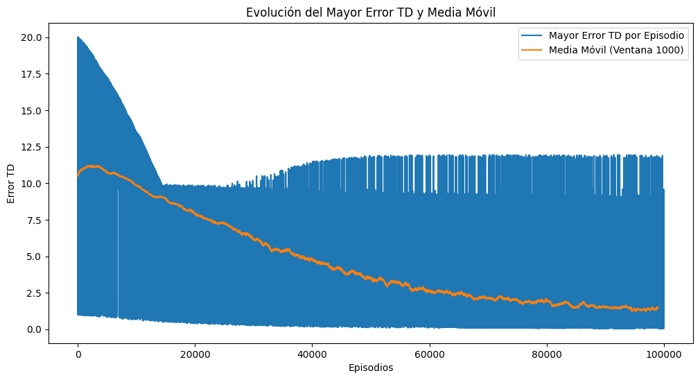

```python
######################## SOLUCIÓN ###########################
# Calcular la media móvil con una ventana temporal de 1000 episodios
moving_average = np.convolve(episode_errors, np.ones(1000)/1000, mode='valid')

# Graficar la evolución del mayor error TD y la media móvil
plt.figure(figsize=(12, 6))
plt.plot(episode_errors, label='Mayor Error TD por Episodio')
plt.plot(np.arange(len(moving_average)), moving_average, label='Media Móvil (Ventana 1000)')
plt.xlabel('Episodios')
plt.ylabel('Error TD')
plt.legend()
plt.title('Evolución del Mayor Error TD y Media Móvil')
plt.show()
```

**Ejercicio 4.3** (0.25 pts)

Implementar una función que ejecute el agente entrenado mediante el método de SARSA durante un número de episodios determinado y que calcule:

- El número total de pasos realizados en el total de episodios.
- El número total de veces que se ha recibido una recompensa de -10 (que equivale al número de veces que se ha llevado a cabo la opción recoger o depositar al pasajero de forma errónea).
- La suma de los retornos de todos los episodios
- El número total de veces que se ha depositado correctamente al pasajero en el destino.

```python
def TD_evaluation(Q ,episodes=100):
    total_epochs, total_return, total_penalties, total_drops = 0, 0, 0, 0
    for _ in range(episodes):
        state = env.reset()
        episode_epochs, episode_return, episode_penalties, episode_drops = 0, 0, 0, 0

        while True:
            action = np.argmax(Q[state, :])
            next_state, reward, done, _ = env.step(action)

            episode_return += reward
            episode_epochs += 1

            if reward == -10:
                episode_penalties += 1

            if done:
                if reward == 20:  # Si el pasajero ha sido entregado correctamente
                    episode_drops += 1
                break

            state = next_state

        total_epochs += episode_epochs
        total_return += episode_return
        total_penalties += episode_penalties
        total_drops += episode_drops

    return total_epochs, total_penalties, total_return, total_drops
```

Una vez implementada la función procederemos a ejecutar unos cuantos episodios y comentar los resultados obtenidos.

```python
episodes = 1000

total_epochs, total_penalties, total_return, total_drops = TD_evaluation(Q, episodes) #Q_sarsa es la tabla de la función Q(s,a) del algoritmo TD entrenado

print("Resultados después de {} episodios:".format(episodes))
print("Número medio de iteraciones por episodio: {}".format(total_epochs / episodes))
print("Número medio de penalizaciones por episodio: {}".format(total_penalties / episodes))
print("Retorno medio por episodio: {}".format(total_return / episodes))
print("Porcentaje de entregas: {} %".format(total_drops*100 / episodes))
```

```
Resultados después de 1000 episodios:
Número medio de iteraciones por episodio: 167.473
Número medio de penalizaciones por episodio: 0.0
Retorno medio por episodio: -163.882
Porcentaje de entregas: 17.1 %
```

Podemos observar que con la politica TD se ha conseguido disminuir las iteraciones medias por episodio, no se ha penalizado por incumplimiento o error de soltar al pasajero cuando no le correspondia, se ha reducido el numero de retorno y se ha conseguido un porcentaje de aciertos del 17.1%

**Ejercicio 4.4** (0.75 pts)

Comparad los resultados obtenidos en este apartado con los obtenidos para el método de Montecarlo del apartado anterior.

- ¿Quién obtiene un mayor retorno?
- ¿Quién obtiene menos penalizaciones?
- ¿Quién tiene un mayor porcentaje de éxitos en la tarea a resolver?
- ¿Quién tarda menos en entrenarse?

## 5. Análisis y fine-tunning del algoritmo TD (2 puntos)

Dadas las mejores prestaciones del algoritmo TD frente al algoritmo de Montecarlo, en este apartado realizaremos un análisis de algunos de los hiperparámetros del algoritmo con el fin de aumentar aún más sus prestaciones.

Analizaremos el comportamiento del algoritmo al modificar el número de episodios de entrenamiento, el valor del *learning rate* y el del factor de descuento.

Para cada ejercicio se deben mostrar y justificar los resultados.

NOTA: se recomienda realizar varias veces las simulaciones en cada ejercicio, ya que éstas son aleatorias, y comentar el resultado más frecuente, o una media de estos.

**Ejercicio 5.1-Influencia del número de episodios** (0.5 pts)

Realizar un estudio cambiando el número de episodios de la siguiente forma:

- Entrenar el algoritmo con 50.000, 100.000, 500.000 y 1.000.0000 de episodios.
- Indicar cómo influye el número de episodios en las métricas estudiadas en los apartados anteriores, para ello realizar un test con 1000 episodios después de cada entrenamiento.

NOTA: Se recomienda realizar alguna gráfica de la evolución de dichas métricas en función del número de episodios de entrenamiento.

```python
######################## SOLUCIÓN 50.000 episodios ###########################

%%time

Q, episode_errors= sarsa(50000, 0.001, 0.6, 0.01)
```

```
Episode 50000/50000.CPU times: user 4min 43s, sys: 22.5 s, total: 5min 5s
Wall time: 5min
```

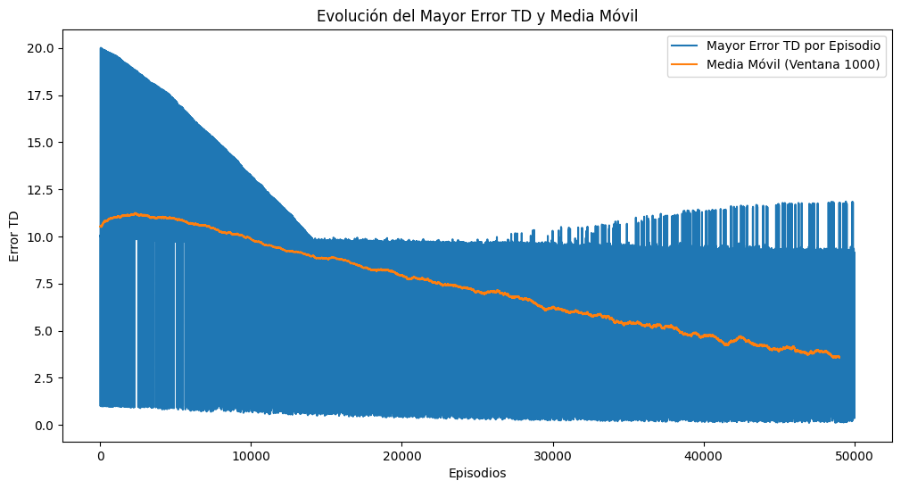

```python
######################## SOLUCIÓN 50.000 episodios ###########################

moving_average = np.convolve(episode_errors, np.ones(1000)/1000, mode='valid')

# Graficar la evolución del mayor error TD y la media móvil
plt.figure(figsize=(12, 6))
plt.plot(episode_errors, label='Mayor Error TD por Episodio')
plt.plot(np.arange(len(moving_average)), moving_average, label='Media Móvil (Ventana 1000)')
plt.xlabel('Episodios')
plt.ylabel('Error TD')
plt.legend()
plt.title('Evolución del Mayor Error TD y Media Móvil')
plt.show()
```

```python
######################## SOLUCIÓN 50.000 episodios ###########################
episodes = 1000

total_epochs, total_penalties, total_return, total_drops = TD_evaluation(Q, episodes) #Q_sarsa es la tabla de la función Q(s,a) del algoritmo TD entrenado

print("Resultados después de {} episodios:".format(episodes))
print("Número medio de iteraciones por episodio: {}".format(total_epochs / episodes))
print("Número medio de penalizaciones por episodio: {}".format(total_penalties / episodes))
print("Retorno medio por episodio: {}".format(total_return / episodes))
print("Porcentaje de entregas: {} %".format(total_drops*100 / episodes))
```

```
Resultados después de 1000 episodios:
Número medio de iteraciones por episodio: 195.578
Número medio de penalizaciones por episodio: 0.0
Retorno medio por episodio: -195.095
Porcentaje de entregas: 2.3 %
```

```python
######################## SOLUCIÓN 100000 episodios ###########################

%%time

Q, episode_errors= sarsa(100000, 0.001, 0.6, 0.01)
```

```
Episode 100000/100000.CPU times: user 6min 54s, sys: 33.1 s, total: 7min 27s
Wall time: 7min 22s
```

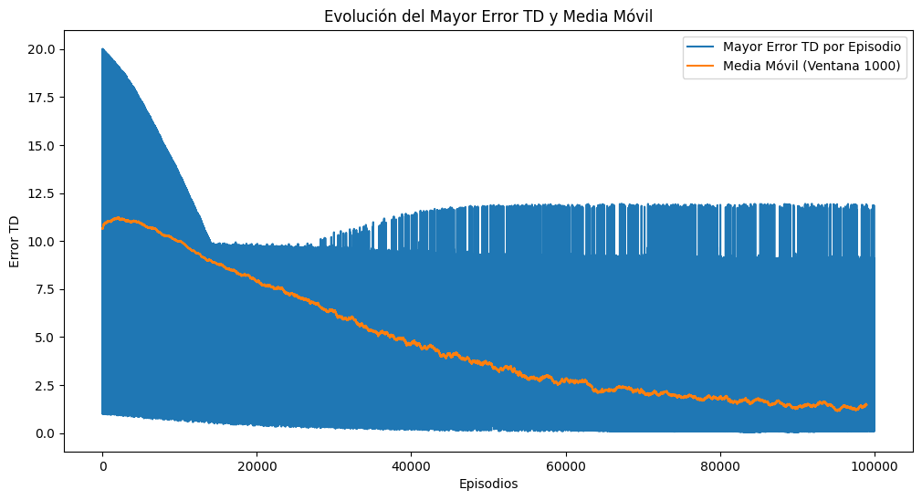

```python
######################## SOLUCIÓN ###########################
moving_average = np.convolve(episode_errors, np.ones(1000)/1000, mode='valid')

# Graficar la evolución del mayor error TD y la media móvil
plt.figure(figsize=(12, 6))
plt.plot(episode_errors, label='Mayor Error TD por Episodio')
plt.plot(np.arange(len(moving_average)), moving_average, label='Media Móvil (Ventana 1000)')
plt.xlabel('Episodios')
plt.ylabel('Error TD')
plt.legend()
plt.title('Evolución del Mayor Error TD y Media Móvil')
plt.show()
```

```python
######################## SOLUCIÓN 100000 episodios ###########################
episodes = 1000

total_epochs, total_penalties, total_return, total_drops = TD_evaluation(Q, episodes) #Q_sarsa es la tabla de la función Q(s,a) del algoritmo TD entrenado

print("Resultados después de {} episodios:".format(episodes))
print("Número medio de iteraciones por episodio: {}".format(total_epochs / episodes))
print("Número medio de penalizaciones por episodio: {}".format(total_penalties / episodes))
print("Retorno medio por episodio: {}".format(total_return / episodes))
print("Porcentaje de entregas: {} %".format(total_drops*100 / episodes))
```

```
Resultados después de 1000 episodios:
Número medio de iteraciones por episodio: 160.492
Número medio de penalizaciones por episodio: 0.0
Retorno medio por episodio: -156.124
Porcentaje de entregas: 20.8 %
```

```python
######################## SOLUCIÓN ###########################
%%time

Q, episode_errors= sarsa(500000, 0.001, 0.6, 0.01)
```

```
Episode 500000/500000.CPU times: user 13min 39s, sys: 1min 4s, total: 14min 44s
Wall time: 15min 5s
```

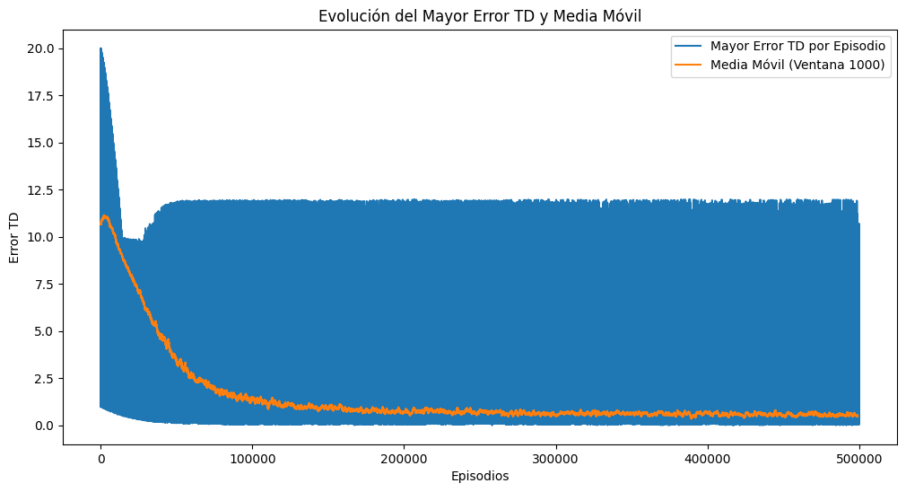

```python
######################## SOLUCIÓN ###########################
moving_average = np.convolve(episode_errors, np.ones(1000)/1000, mode='valid')

# Graficar la evolución del mayor error TD y la media móvil
plt.figure(figsize=(12, 6))
plt.plot(episode_errors, label='Mayor Error TD por Episodio')
plt.plot(np.arange(len(moving_average)), moving_average, label='Media Móvil (Ventana 1000)')
plt.xlabel('Episodios')
plt.ylabel('Error TD')
plt.legend()
plt.title('Evolución del Mayor Error TD y Media Móvil')
plt.show()
```

```python
######################## SOLUCIÓN ###########################
episodes = 1000

total_epochs, total_penalties, total_return, total_drops = TD_evaluation(Q, episodes) #Q_sarsa es la tabla de la función Q(s,a) del algoritmo TD entrenado

print("Resultados después de {} episodios:".format(episodes))
print("Número medio de iteraciones por episodio: {}".format(total_epochs / episodes))
print("Número medio de penalizaciones por episodio: {}".format(total_penalties / episodes))
print("Retorno medio por episodio: {}".format(total_return / episodes))
print("Porcentaje de entregas: {} %".format(total_drops*100 / episodes))
```

```
Resultados después de 1000 episodios:
Número medio de iteraciones por episodio: 66.859
Número medio de penalizaciones por episodio: 0.0
Retorno medio por episodio: -51.949
Porcentaje de entregas: 71.0 %
```

```python
######################## SOLUCIÓN ###########################
%%time

Q, episode_errors= sarsa(1000000, 0.001, 0.6, 0.01)
```

```
Episode 1000000/1000000.CPU times: user 20min 20s, sys: 1min 34s, total: 21min 55s
Wall time: 22min 58s
```

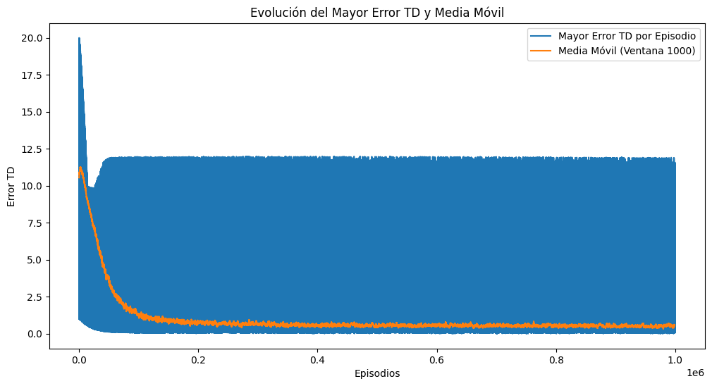

```python
######################## SOLUCIÓN ###########################
moving_average = np.convolve(episode_errors, np.ones(1000)/1000, mode='valid')

# Graficar la evolución del mayor error TD y la media móvil
plt.figure(figsize=(12, 6))
plt.plot(episode_errors, label='Mayor Error TD por Episodio')
plt.plot(np.arange(len(moving_average)), moving_average, label='Media Móvil (Ventana 1000)')
plt.xlabel('Episodios')
plt.ylabel('Error TD')
plt.legend()
plt.title('Evolución del Mayor Error TD y Media Móvil')
plt.show()
```

```python
######################## SOLUCIÓN ###########################
episodes = 1000

total_epochs, total_penalties, total_return, total_drops = TD_evaluation(Q, episodes) #Q_sarsa es la tabla de la función Q(s,a) del algoritmo TD entrenado

print("Resultados después de {} episodios:".format(episodes))
print("Número medio de iteraciones por episodio: {}".format(total_epochs / episodes))
print("Número medio de penalizaciones por episodio: {}".format(total_penalties / episodes))
print("Retorno medio por episodio: {}".format(total_return / episodes))
print("Porcentaje de entregas: {} %".format(total_drops*100 / episodes))
```

```
Resultados después de 1000 episodios:
Número medio de iteraciones por episodio: 31.655
Número medio de penalizaciones por episodio: 0.0
Retorno medio por episodio: -12.776
Porcentaje de entregas: 89.9 %
```

**Comentarios:**  
Como podemos observar en las graficas de los errores y los resultados del entrenamiento, podemos llegar a la conclusion de que cuanto mas episodios utiliza para aprender mejor es la proximación al exito. Cabe destacar que a partir de unos 200.000 episodios, el error disminuye con menos volumen por lo que llega a un punto que el tiempo de ejecion se ve mas afectado en comparacion a la mejora del algoritmo.

**Ejercicio 5.2-Influencia del learning rate** (0.5 pts)

Ejecutar el algoritmo de *SARSA* con los siguientes valores de *learning rate*: 0.001, 0.01, 0.1 y 0.9 manteniendo el valor del resto de hiperparámetros utilizados en el ejercicio 4. Analizar las diferencias con los resultados obtenidos en la pregunta 4 respecto a las métricas analizadas en ese apartado. De nuevo, una gráfica con la evolucxión de dichas medidas en función del *learning rate* utilizado puede ser de utilidad.

```python
######################## SOLUCIÓN ###########################
%%time

Q, episode_errors= sarsa(100000, 0.001, 0.6, 0.01)
```

```
Episode 100000/100000.CPU times: user 6min 55s, sys: 33.2 s, total: 7min 28s
Wall time: 7min 23s
```

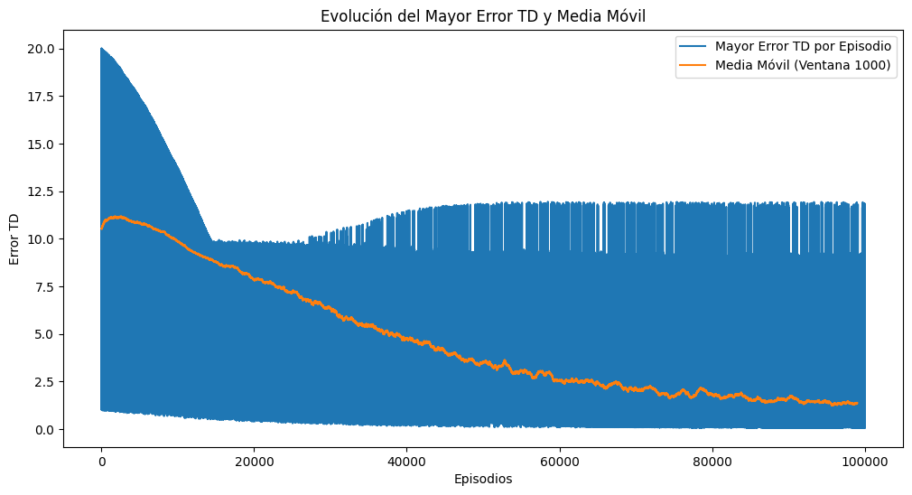

```python
######################## SOLUCIÓN ###########################
moving_average = np.convolve(episode_errors, np.ones(1000)/1000, mode='valid')

# Graficar la evolución del mayor error TD y la media móvil
plt.figure(figsize=(12, 6))
plt.plot(episode_errors, label='Mayor Error TD por Episodio')
plt.plot(np.arange(len(moving_average)), moving_average, label='Media Móvil (Ventana 1000)')
plt.xlabel('Episodios')
plt.ylabel('Error TD')
plt.legend()
plt.title('Evolución del Mayor Error TD y Media Móvil')
plt.show()
```

```python
######################## SOLUCIÓN ###########################

episodes = 1000

total_epochs, total_penalties, total_return, total_drops = TD_evaluation(Q, episodes) #Q_sarsa es la tabla de la función Q(s,a) del algoritmo TD entrenado

print("Resultados después de {} episodios:".format(episodes))
print("Número medio de iteraciones por episodio: {}".format(total_epochs / episodes))
print("Número medio de penalizaciones por episodio: {}".format(total_penalties / episodes))
print("Retorno medio por episodio: {}".format(total_return / episodes))
print("Porcentaje de entregas: {} %".format(total_drops*100 / episodes))
```

```
Resultados después de 1000 episodios:
Número medio de iteraciones por episodio: 156.806
Número medio de penalizaciones por episodio: 0.0
Retorno medio por episodio: -152.039
Porcentaje de entregas: 22.7 %
```

```python
######################## SOLUCIÓN ###########################

%%time

Q, episode_errors= sarsa(100000, 0.01, 0.6, 0.01)
```

```
Episode 100000/100000.CPU times: user 2min 3s, sys: 9.63 s, total: 2min 13s
Wall time: 2min 19s
```

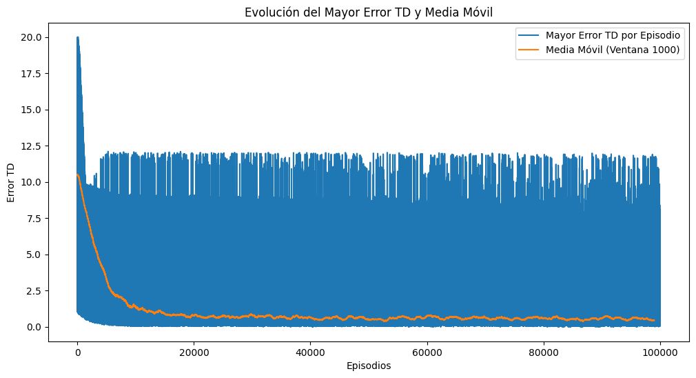

```python
######################## SOLUCIÓN ###########################

moving_average = np.convolve(episode_errors, np.ones(1000)/1000, mode='valid')

# Graficar la evolución del mayor error TD y la media móvil
plt.figure(figsize=(12, 6))
plt.plot(episode_errors, label='Mayor Error TD por Episodio')
plt.plot(np.arange(len(moving_average)), moving_average, label='Media Móvil (Ventana 1000)')
plt.xlabel('Episodios')
plt.ylabel('Error TD')
plt.legend()
plt.title('Evolución del Mayor Error TD y Media Móvil')
plt.show()
```

```python
######################## SOLUCIÓN ###########################

episodes = 1000

total_epochs, total_penalties, total_return, total_drops = TD_evaluation(Q, episodes) #Q_sarsa es la tabla de la función Q(s,a) del algoritmo TD entrenado

print("Resultados después de {} episodios:".format(episodes))
print("Número medio de iteraciones por episodio: {}".format(total_epochs / episodes))
print("Número medio de penalizaciones por episodio: {}".format(total_penalties / episodes))
print("Retorno medio por episodio: {}".format(total_return / episodes))
print("Porcentaje de entregas: {} %".format(total_drops*100 / episodes))
```

```
Resultados después de 1000 episodios:
Número medio de iteraciones por episodio: 32.189
Número medio de penalizaciones por episodio: 0.0
Retorno medio por episodio: -13.352
Porcentaje de entregas: 89.7 %
```

```python
######################## SOLUCIÓN ###########################
%%time

Q, episode_errors= sarsa(100000, 0.1, 0.6, 0.01)
```

```
Episode 100000/100000.CPU times: user 2min 55s, sys: 14.8 s, total: 3min 10s
Wall time: 3min 14s
```

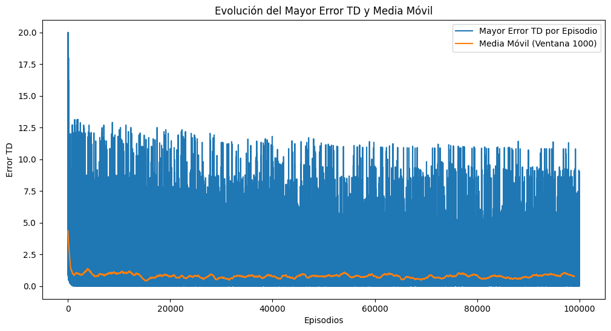

```python
######################## SOLUCIÓN ###########################

moving_average = np.convolve(episode_errors, np.ones(1000)/1000, mode='valid')

# Graficar la evolución del mayor error TD y la media móvil
plt.figure(figsize=(12, 6))
plt.plot(episode_errors, label='Mayor Error TD por Episodio')
plt.plot(np.arange(len(moving_average)), moving_average, label='Media Móvil (Ventana 1000)')
plt.xlabel('Episodios')
plt.ylabel('Error TD')
plt.legend()
plt.title('Evolución del Mayor Error TD y Media Móvil')
plt.show()
```

```python
######################## SOLUCIÓN ###########################

episodes = 1000

total_epochs, total_penalties, total_return, total_drops = TD_evaluation(Q, episodes) #Q_sarsa es la tabla de la función Q(s,a) del algoritmo TD entrenado

print("Resultados después de {} episodios:".format(episodes))
print("Número medio de iteraciones por episodio: {}".format(total_epochs / episodes))
print("Número medio de penalizaciones por episodio: {}".format(total_penalties / episodes))
print("Retorno medio por episodio: {}".format(total_return / episodes))
print("Porcentaje de entregas: {} %".format(total_drops*100 / episodes))
```

```
Resultados después de 1000 episodios:
Número medio de iteraciones por episodio: 55.446
Número medio de penalizaciones por episodio: 0.0
Retorno medio por episodio: -39.087
Porcentaje de entregas: 77.9 %
```

```python
######################## SOLUCIÓN ###########################

%%time

Q, episode_errors= sarsa(100000, 0.9, 0.6, 0.01)
```

```
Episode 100000/100000.CPU times: user 9min 27s, sys: 40.4 s, total: 10min 8s
Wall time: 10min 44s
```

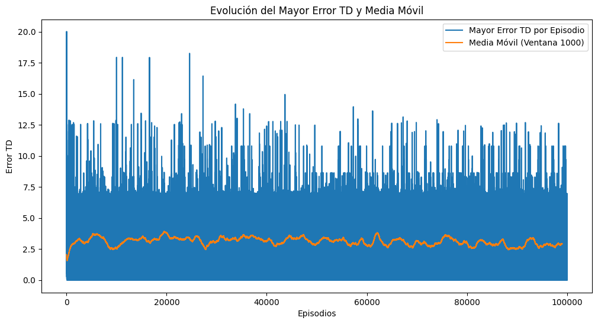

```python
######################## SOLUCIÓN ###########################


moving_average = np.convolve(episode_errors, np.ones(1000)/1000, mode='valid')

# Graficar la evolución del mayor error TD y la media móvil
plt.figure(figsize=(12, 6))
plt.plot(episode_errors, label='Mayor Error TD por Episodio')
plt.plot(np.arange(len(moving_average)), moving_average, label='Media Móvil (Ventana 1000)')
plt.xlabel('Episodios')
plt.ylabel('Error TD')
plt.legend()
plt.title('Evolución del Mayor Error TD y Media Móvil')
plt.show()
```

```python
######################## SOLUCIÓN ###########################

episodes = 1000

total_epochs, total_penalties, total_return, total_drops = TD_evaluation(Q, episodes) #Q_sarsa es la tabla de la función Q(s,a) del algoritmo TD entrenado

print("Resultados después de {} episodios:".format(episodes))
print("Número medio de iteraciones por episodio: {}".format(total_epochs / episodes))
print("Número medio de penalizaciones por episodio: {}".format(total_penalties / episodes))
print("Retorno medio por episodio: {}".format(total_return / episodes))
print("Porcentaje de entregas: {} %".format(total_drops*100 / episodes))
```

```
Resultados después de 1000 episodios:
Número medio de iteraciones por episodio: 137.84
Número medio de penalizaciones por episodio: 0.0
Retorno medio por episodio: -130.847
Porcentaje de entregas: 33.3 %
```

**Comentarios:**  
Podemos observar como con el learning rate 0.01 nos da un un porcentaje de exito del 89 % de aciertos en 1000 episodios y un tiempo de ejecucion mas bajo de 2 min aproximadamente.

**Ejercicio 5.3-Influencia del factor de descuento** (0.5 pts)

Ejecutar el algoritmo de *SARSA* con los siguientes valores para el factor de descuento: 0.1, 0.6 y 0.9 manteniendo el valor del resto de hiperparámetros utilizados en el ejercicio 4. Analizar las diferencias con los resultados obtenidos en la pregunta 4 respecto a las métricas analizadas en ese apartado. De nuevo, una gráfica con la evolución de dichas medidas en función del *Discount factor* utilizado puede ser de utilidad.

```python
######################## SOLUCIÓN ###########################
%%time

Q, episode_errors= sarsa(100000, 0.001, 0.1, 0.01)
```

```
Episode 100000/100000.CPU times: user 10min 39s, sys: 46.4 s, total: 11min 25s
Wall time: 11min 40s
```

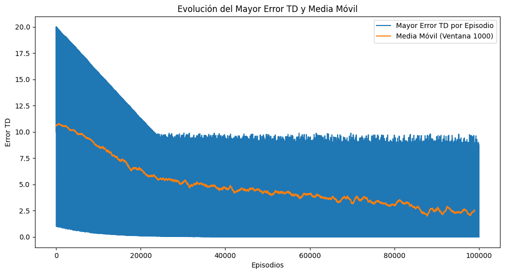

```python
######################## SOLUCIÓN ###########################
moving_average = np.convolve(episode_errors, np.ones(1000)/1000, mode='valid')

# Graficar la evolución del mayor error TD y la media móvil
plt.figure(figsize=(12, 6))
plt.plot(episode_errors, label='Mayor Error TD por Episodio')
plt.plot(np.arange(len(moving_average)), moving_average, label='Media Móvil (Ventana 1000)')
plt.xlabel('Episodios')
plt.ylabel('Error TD')
plt.legend()
plt.title('Evolución del Mayor Error TD y Media Móvil')
plt.show()
```

```python
######################## SOLUCIÓN ###########################
episodes = 1000

total_epochs, total_penalties, total_return, total_drops = TD_evaluation(Q, episodes) #Q_sarsa es la tabla de la función Q(s,a) del algoritmo TD entrenado

print("Resultados después de {} episodios:".format(episodes))
print("Número medio de iteraciones por episodio: {}".format(total_epochs / episodes))
print("Número medio de penalizaciones por episodio: {}".format(total_penalties / episodes))
print("Retorno medio por episodio: {}".format(total_return / episodes))
print("Porcentaje de entregas: {} %".format(total_drops*100 / episodes))
```

```
Resultados después de 1000 episodios:
Número medio de iteraciones por episodio: 200.0
Número medio de penalizaciones por episodio: 0.0
Retorno medio por episodio: -200.0
Porcentaje de entregas: 0.0 %
```

```python
######################## SOLUCIÓN ###########################
Q, episode_errors= sarsa(100000, 0.001, 0.6, 0.01)
```

```
Episode 100000/100000.
```

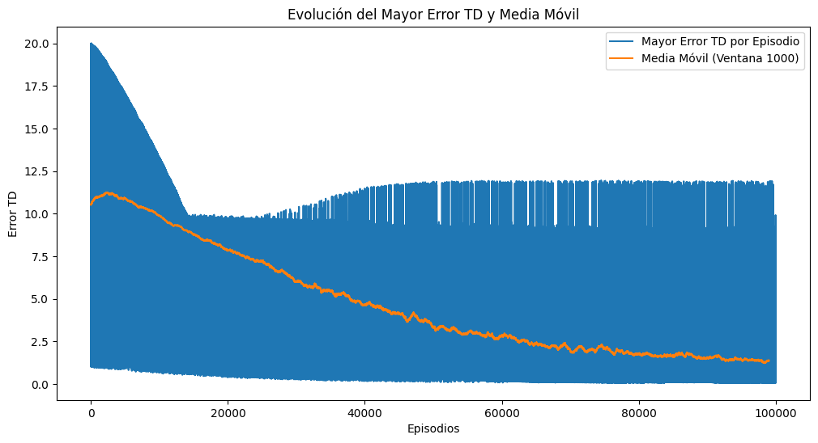

```python
######################## SOLUCIÓN ###########################
moving_average = np.convolve(episode_errors, np.ones(1000)/1000, mode='valid')

# Graficar la evolución del mayor error TD y la media móvil
plt.figure(figsize=(12, 6))
plt.plot(episode_errors, label='Mayor Error TD por Episodio')
plt.plot(np.arange(len(moving_average)), moving_average, label='Media Móvil (Ventana 1000)')
plt.xlabel('Episodios')
plt.ylabel('Error TD')
plt.legend()
plt.title('Evolución del Mayor Error TD y Media Móvil')
plt.show()
```

```python
######################## SOLUCIÓN ###########################
episodes = 1000

total_epochs, total_penalties, total_return, total_drops = TD_evaluation(Q, episodes) #Q_sarsa es la tabla de la función Q(s,a) del algoritmo TD entrenado

print("Resultados después de {} episodios:".format(episodes))
print("Número medio de iteraciones por episodio: {}".format(total_epochs / episodes))
print("Número medio de penalizaciones por episodio: {}".format(total_penalties / episodes))
print("Retorno medio por episodio: {}".format(total_return / episodes))
print("Porcentaje de entregas: {} %".format(total_drops*100 / episodes))
```

```
Resultados después de 1000 episodios:
Número medio de iteraciones por episodio: 164.044
Número medio de penalizaciones por episodio: 0.0
Retorno medio por episodio: -160.075
Porcentaje de entregas: 18.9 %
```

```python
######################## SOLUCIÓN ###########################
Q, episode_errors= sarsa(100000, 0.001, 0.9, 0.01)
```

```
Episode 100000/100000.
```

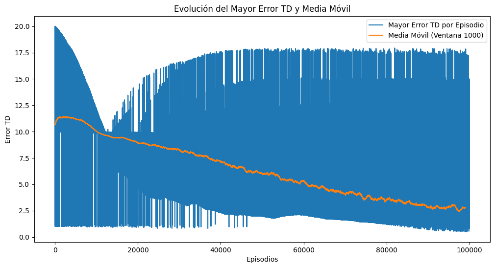

```python
######################## SOLUCIÓN ###########################
moving_average = np.convolve(episode_errors, np.ones(1000)/1000, mode='valid')

# Graficar la evolución del mayor error TD y la media móvil
plt.figure(figsize=(12, 6))
plt.plot(episode_errors, label='Mayor Error TD por Episodio')
plt.plot(np.arange(len(moving_average)), moving_average, label='Media Móvil (Ventana 1000)')
plt.xlabel('Episodios')
plt.ylabel('Error TD')
plt.legend()
plt.title('Evolución del Mayor Error TD y Media Móvil')
plt.show()
```

```python
######################## SOLUCIÓN ###########################
episodes = 1000

total_epochs, total_penalties, total_return, total_drops = TD_evaluation(Q, episodes) #Q_sarsa es la tabla de la función Q(s,a) del algoritmo TD entrenado

print("Resultados después de {} episodios:".format(episodes))
print("Número medio de iteraciones por episodio: {}".format(total_epochs / episodes))
print("Número medio de penalizaciones por episodio: {}".format(total_penalties / episodes))
print("Retorno medio por episodio: {}".format(total_return / episodes))
print("Porcentaje de entregas: {} %".format(total_drops*100 / episodes))
```

```
Resultados después de 1000 episodios:
Número medio de iteraciones por episodio: 106.907
Número medio de penalizaciones por episodio: 3.19
Retorno medio por episodio: -125.264
Porcentaje de entregas: 49.3 %
```

**Comentarios:**  
Como podemos observar cambiando solamente el factor de descuento podemos observar que a cuanto mayor descuento mejor porcentaje de exito tiene el algoritmo entrenado.

**Ejercicio 5.4-Selección de los mejores hiperparámetros** (0.5 pts)

En base a los hiperparámetros estudiados en los apartados anteriores realizar una selección de los mejores hiperparámetros con el objetivo de obtener los mejores resultados con el entrenamiento más corto posible.

```python
######################## SOLUCIÓN ###########################
Q, episode_errors= sarsa(500000, 0.01, 0.9, 0.01)
```

```
Episode 500000/500000.
```

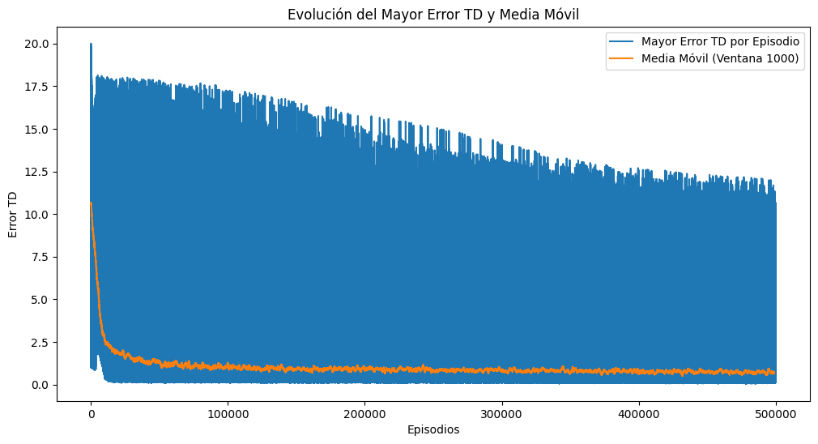

```python
moving_average = np.convolve(episode_errors, np.ones(1000)/1000, mode='valid')

# Graficar la evolución del mayor error TD y la media móvil
plt.figure(figsize=(12, 6))
plt.plot(episode_errors, label='Mayor Error TD por Episodio')
plt.plot(np.arange(len(moving_average)), moving_average, label='Media Móvil (Ventana 1000)')
plt.xlabel('Episodios')
plt.ylabel('Error TD')
plt.legend()
plt.title('Evolución del Mayor Error TD y Media Móvil')
plt.show()
```

```python
episodes = 1000

total_epochs, total_penalties, total_return, total_drops = TD_evaluation(Q, episodes) #Q_sarsa es la tabla de la función Q(s,a) del algoritmo TD entrenado

print("Resultados después de {} episodios:".format(episodes))
print("Número medio de iteraciones por episodio: {}".format(total_epochs / episodes))
print("Número medio de penalizaciones por episodio: {}".format(total_penalties / episodes))
print("Retorno medio por episodio: {}".format(total_return / episodes))
print("Porcentaje de entregas: {} %".format(total_drops*100 / episodes))
```

```
Resultados después de 1000 episodios:
Número medio de iteraciones por episodio: 13.186
Número medio de penalizaciones por episodio: 0.0
Retorno medio por episodio: 7.814
Porcentaje de entregas: 100.0 %
```

**Comentarios:**  
Al utilizar los parametros que mejor han entrenado en los diferentes apartados anteiores podemos observar que el algoritmo ha aprendido correctamente y encuentra con exito el 100 % de los episodios. Cabe destacar que, tambien se podria llegar al mismo porcentaje disminuyendo el numero de episodios por la representacion de la grafica.

## 6. Mejora de resultados (1 punto)

En este último apartado se deja libertad al alumno para conseguir, mediante la elección de otro algoritmo, unos mejores resultados en la encomendada, ya sea con una mejor performance o manteniendo la performance pero reduciendo el tiempo de entrenamiento.

Se valorarará la justificación de las elecciones realizadas.

**Ejercicio 6.1**(1 pt): Implementar un agente para resolver el entorno **Taxi**

- Implementar el algoritmo
- Llevar a cabo el entrenamientio
- Evaluar el modelo presentando las métricas y gráficas adecuadas
- Comentar la elección realizada así como los resultados obtenidos

Para realizar este ejercicio se ha adaptado de este enlace: https://github.com/lhvy/Taxi-v3-Q-Learning/blob/master/agent.py

```
Resultados después de 1000 episodios:
Número medio de iteraciones por episodio: 14.706
Número medio de penalizaciones por episodio: 0.446
Retorno medio por episodio: 2.28
Porcentaje de entregas: 100.0 %
```

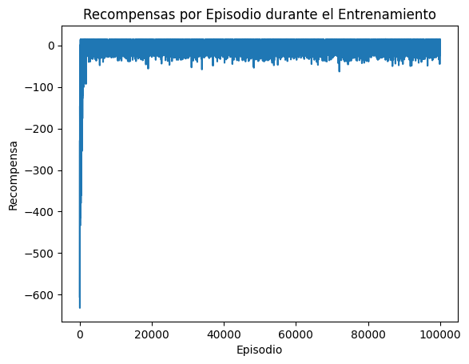

```python
import numpy as np
import gym
import matplotlib.pyplot as plt

def epsilon_greedy(Q, state, epsilon):
    if np.random.rand() < epsilon:
        return env.action_space.sample()
    else:
        return np.argmax(Q[state, :])

def Q_learning_evaluation(Q, episodes=100):
    total_epochs, total_penalties, total_return, total_drops = 0, 0, 0, 0

    for _ in range(episodes):
        state = env.reset()
        episode_return = 0
        episode_epochs = 0
        episode_penalties = 0
        episode_drops = 0

        while True:
            action = epsilon_greedy(Q, state, epsilon)
            next_state, reward, done, _ = env.step(action)

            episode_return += reward
            episode_epochs += 1

            if reward == -10:
                episode_penalties += 1

            if reward == 20:
                episode_drops += 1

            if done:
                break

            state = next_state

        total_return += episode_return
        total_epochs += episode_epochs
        total_penalties += episode_penalties
        total_drops += episode_drops

    return total_epochs, total_penalties, total_return, total_drops

# Crear el entorno del problema de Taxi
env = gym.make("Taxi-v3")

# Inicializar la tabla Q con ceros
num_states = env.observation_space.n
num_actions = env.action_space.n
Q = np.zeros((num_states, num_actions))

# Parámetros del algoritmo Q-learning
alpha = 0.1  # Tasa de aprendizaje
gamma = 0.99  # Factor de descuento
epsilon = 0.1  # Exploración vs. explotación

# Entrenamiento del agente
num_episodes = 100000
rewards = []

for episode in range(num_episodes):
    state = env.reset()
    episode_reward = 0

    while True:
        action = epsilon_greedy(Q, state, epsilon)
        next_state, reward, done, _ = env.step(action)

        # Actualizar la tabla Q
        Q[state, action] = (1 - alpha) * Q[state, action] + alpha * (reward + gamma * np.max(Q[next_state, :]))

        episode_reward += reward
        state = next_state

        if done:
            break

    rewards.append(episode_reward)

# Evaluar el modelo con la función Q-learning
evaluation_episodes = 1000
total_epochs, total_penalties, total_return, total_drops = Q_learning_evaluation(Q, evaluation_episodes)

print("Resultados después de {} episodios:".format(evaluation_episodes))
print("Número medio de iteraciones por episodio: {}".format(total_epochs / evaluation_episodes))
print("Número medio de penalizaciones por episodio: {}".format(total_penalties / evaluation_episodes))
print("Retorno medio por episodio: {}".format(total_return / evaluation_episodes))
print("Porcentaje de entregas: {} %".format(total_drops * 100 / evaluation_episodes))

# Graficar las recompensas por episodio durante el entrenamiento
plt.plot(rewards)
plt.title('Recompensas por Episodio durante el Entrenamiento')
plt.xlabel('Episodio')
plt.ylabel('Recompensa')
plt.show()
```

**Comentarios:**  
Implementando el algoritmo Q learning entrenado con 100.000 episodios y unas variables Tasa de aprendizaje 0.1, Factor de descuento 0.99 y epsilon = 0.1 se ha conseguido llegar a la solucion el 100 % de los episodios. Observando la grafica podriamos entrenar el algoritmo con menos episodios para mejorar su tiempo de ejecucion.